# 知识分析与应用基础 实验 1：KNN

本实验要求自己实现 KNN 算法，并作用于 Iris 数据集的分类。

## 准备工作

```python
import numpy as np
import pandas as pd
import seaborn as sns
import matplotlib.pyplot as plt
from sklearn.model_selection import train_test_split

sns.set(color_codes=True)
%matplotlib inline
```

```python
train_df = pd.read_csv("train.csv", header=None)
```

```python
train_df.columns = ["SepalLengthCm", "SepalWidthCm", "PetalLengthCm", "PetalWidthCm", "Species"]
```

```python
train_df.head()
```

|  | SepalLengthCm | SepalWidthCm | PetalLengthCm | PetalWidthCm | Species |
| --- | --- | --- | --- | --- | --- |
| 0 | 5.1 | 3.5 | 1.4 | 0.2 | Iris-setosa |
| 1 | 4.9 | 3.0 | 1.4 | 0.2 | Iris-setosa |
| 2 | 4.7 | 3.2 | 1.3 | 0.2 | Iris-setosa |
| 3 | 4.6 | 3.1 | 1.5 | 0.2 | Iris-setosa |
| 4 | 5.0 | 3.6 | 1.4 | 0.2 | Iris-setosa |

## 数据分析

```python
train_df.describe()
```

|  | SepalLengthCm | SepalWidthCm | PetalLengthCm | PetalWidthCm |
| --- | --- | --- | --- | --- |
| count | 120.00000 | 120.000000 | 120.000000 | 120.000000 |
| mean | 5.89000 | 3.060000 | 3.795833 | 1.190833 |
| std | 0.84589 | 0.441807 | 1.792861 | 0.757372 |
| min | 4.30000 | 2.000000 | 1.000000 | 0.100000 |
| 25% | 5.17500 | 2.800000 | 1.575000 | 0.300000 |
| 50% | 5.80000 | 3.000000 | 4.450000 | 1.400000 |
| 75% | 6.40000 | 3.325000 | 5.100000 | 1.800000 |
| max | 7.90000 | 4.400000 | 6.900000 | 2.500000 |

```
array([[<matplotlib.axes._subplots.AxesSubplot object at 0x116d80358>,
        <matplotlib.axes._subplots.AxesSubplot object at 0x116ed6208>]], dtype=object)
```

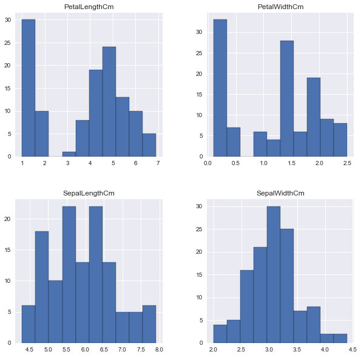

```python
train_df.hist(edgecolor="black", figsize=(10, 10))
```

```
array([[<matplotlib.axes._subplots.AxesSubplot object at 0x112e014e0>,
        <matplotlib.axes._subplots.AxesSubplot object at 0x1143587f0>]], dtype=object)
```

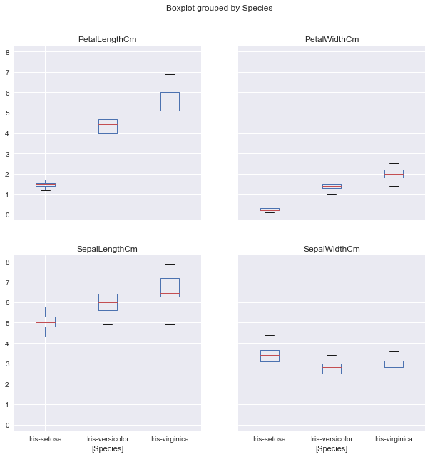

```python
train_df.boxplot(by="Species", figsize=(10, 10))
```

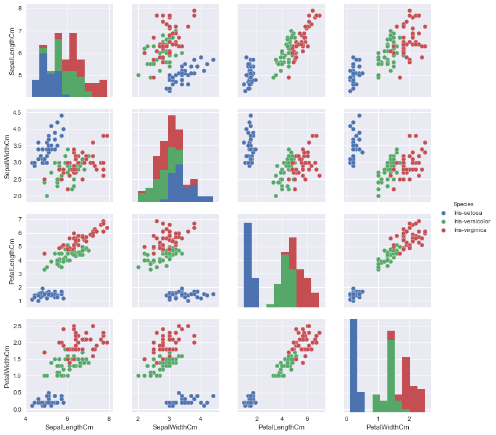

```python
sns.pairplot(train_df, hue="Species")
```

从上图可以看出，大概只需要两个特征，比如 PLC 和 PWC 就可以达到较好的区分效果。尤其是蓝色和绿红，基本不会搞混。

另外由于数据各维度差距不大，我也没有看出 Normalization 的必要性。

## 分类

手动实现 KNN。为了后续实验方便（方便与 Sklearn 库中的 KNN 进行比较），这里实现的 KNN 刻意与 Sklearn 中的参数格式完全相同。

实现的时候参考了 Sklearn 的源码。源码写得很厉害（最后都没看完）！看了大半天还是决定发挥自己的 Python 功底手糊一个。结果没几行就……写完了。

```python
import numpy as np
from sklearn.metrics import accuracy_score
from scipy.spatial.distance import minkowski


def uniform_weight_function(dist):
    return 1.0

def inverse_weight_function(dist):
    return 1. / (dist + 1E-6)


class KNN:
    def __init__(self, n_neighbors=5, weights='uniform', p=2):
        self.n_neighbors = n_neighbors
        if weights == 'uniform':
            self.weights = uniform_weight_function
        elif weights == 'distance':
            self.weights = inverse_weight_function
        else:
            raise NotImplementedError
        self.distance = lambda u, v: minkowski(u, v, p)

    def fit(self, X, y):
        self.X = np.array(X)
        self.y = np.array(y)
        if self.X.shape[0] != self.y.shape[0]:
            raise ValueError("Array dimensions are not consistent.")

    def predict(self, X):
        X = np.array(X)
        ans = []
        classes = set(self.y)
        for sample_idx, v in enumerate(X):
            predicts = {cls: 0.0 for cls in classes}
            score_list = [(self.distance(x, v), self.y[i]) for i, x in enumerate(self.X)]
            score_list.sort()
            scores = np.array([x[0] for x in score_list])
            for i in range(min(self.n_neighbors, len(score_list))):
                predicts[score_list[i][1]] += self.weights(score_list[i][0])
            ans.append(max([(x[1], x[0]) for x in predicts.items()])[1])
        return np.array(ans)

    def score(self, X, y):
        return accuracy_score(self.predict(X), y)
```

调参。对三个参数进行三层 for 循环遍历，每个参数测试 10 次，结果加入一个 DataFrame 表格中，进行后续分析。

```python
from sklearn.neighbors import KNeighborsClassifier

comparison_with_sklearn = pd.DataFrame(columns=["Neighbors", "Weights", "P", "My", "Sklearn"])

# for n_neighbors in [3, 4, 5, 7, 9, 11, 14, 17, 20]:
for n_neighbors in [3, 4, 5, 7, 9]:
    for weights in ('uniform', 'distance'):
        for p in range(1, 6):
            for test in range(10):
                tr, te = train_test_split(train_df)
                tr_x, tr_y = tr[["SepalLengthCm", "SepalWidthCm", "PetalLengthCm", "PetalWidthCm"]], tr["Species"]
                te_x, te_y = te[["SepalLengthCm", "SepalWidthCm", "PetalLengthCm", "PetalWidthCm"]], te["Species"]

                knn = KNN(n_neighbors=n_neighbors, weights=weights, p=p)
                knn.fit(tr_x, tr_y)
                my_knn_score = knn.score(te_x, te_y)

                knn2 = KNeighborsClassifier(n_neighbors=n_neighbors, weights=weights, p=p)
                knn2.fit(tr_x, tr_y)
                sklearn_knn_score = knn2.score(te_x, te_y)
                comparison_with_sklearn.loc[len(comparison_with_sklearn)] = [n_neighbors, weights, p, my_knn_score, sklearn_knn_score]
```

观察答案与 sklearn 不一致的点。（是我写错了吗？为什么会不一致呢？）

但是好像不一致的也不多，就不管了。

```python
comparison_with_sklearn.loc[comparison_with_sklearn.My != comparison_with_sklearn.Sklearn]
```

|  | Neighbors | Weights | P | My | Sklearn |
| --- | --- | --- | --- | --- | --- |
| 100 | 4.0 | uniform | 1.0 | 0.966667 | 1.000000 |
| 101 | 4.0 | uniform | 1.0 | 0.966667 | 0.933333 |
| 102 | 4.0 | uniform | 1.0 | 0.933333 | 0.866667 |
| 105 | 4.0 | uniform | 1.0 | 0.966667 | 0.900000 |
| 106 | 4.0 | uniform | 1.0 | 1.000000 | 0.966667 |
| 107 | 4.0 | uniform | 1.0 | 0.933333 | 0.900000 |
| 108 | 4.0 | uniform | 1.0 | 0.966667 | 0.933333 |
| 109 | 4.0 | uniform | 1.0 | 0.966667 | 0.933333 |
| 111 | 4.0 | uniform | 2.0 | 0.966667 | 0.900000 |
| 112 | 4.0 | uniform | 2.0 | 0.900000 | 0.933333 |
| 114 | 4.0 | uniform | 2.0 | 1.000000 | 0.966667 |
| 115 | 4.0 | uniform | 2.0 | 0.933333 | 1.000000 |
| 116 | 4.0 | uniform | 2.0 | 0.866667 | 0.933333 |
| 117 | 4.0 | uniform | 2.0 | 0.933333 | 0.966667 |
| 120 | 4.0 | uniform | 3.0 | 0.900000 | 0.933333 |
| 122 | 4.0 | uniform | 3.0 | 0.933333 | 0.866667 |
| 123 | 4.0 | uniform | 3.0 | 0.900000 | 0.966667 |
| 125 | 4.0 | uniform | 3.0 | 0.966667 | 0.900000 |
| 126 | 4.0 | uniform | 3.0 | 1.000000 | 0.966667 |
| 128 | 4.0 | uniform | 3.0 | 0.966667 | 0.933333 |
| 130 | 4.0 | uniform | 4.0 | 1.000000 | 0.900000 |
| 131 | 4.0 | uniform | 4.0 | 0.966667 | 0.933333 |
| 134 | 4.0 | uniform | 4.0 | 0.900000 | 0.933333 |
| 135 | 4.0 | uniform | 4.0 | 0.933333 | 0.966667 |
| 137 | 4.0 | uniform | 4.0 | 0.966667 | 0.900000 |
| 138 | 4.0 | uniform | 4.0 | 1.000000 | 0.933333 |
| 139 | 4.0 | uniform | 4.0 | 0.933333 | 1.000000 |
| 141 | 4.0 | uniform | 5.0 | 0.866667 | 0.933333 |
| 142 | 4.0 | uniform | 5.0 | 0.966667 | 0.933333 |
| 143 | 4.0 | uniform | 5.0 | 0.866667 | 0.833333 |
| 146 | 4.0 | uniform | 5.0 | 0.933333 | 0.900000 |
| 148 | 4.0 | uniform | 5.0 | 0.933333 | 0.900000 |
| 149 | 4.0 | uniform | 5.0 | 0.933333 | 1.000000 |
| 200 | 5.0 | uniform | 1.0 | 0.900000 | 0.866667 |
| 300 | 7.0 | uniform | 1.0 | 0.933333 | 0.966667 |
| 350 | 7.0 | distance | 1.0 | 0.933333 | 0.900000 |
| 402 | 9.0 | uniform | 1.0 | 0.933333 | 0.966667 |
| 404 | 9.0 | uniform | 1.0 | 0.933333 | 0.966667 |

比较正确率，发现我的居然比 sklearn 还高一点点……

```python
comparison_with_sklearn.describe()
```

|  | Neighbors | P | My | Sklearn |
| --- | --- | --- | --- | --- |
| count | 500.000000 | 500.00000 | 500.000000 | 500.000000 |
| mean | 5.600000 | 3.00000 | 0.947067 | 0.946333 |
| std | 2.156223 | 1.41563 | 0.040182 | 0.040618 |
| min | 3.000000 | 1.00000 | 0.766667 | 0.766667 |
| 25% | 4.000000 | 2.00000 | 0.933333 | 0.933333 |
| 50% | 5.000000 | 3.00000 | 0.966667 | 0.966667 |
| 75% | 7.000000 | 4.00000 | 0.966667 | 0.966667 |
| max | 9.000000 | 5.00000 | 1.000000 | 1.000000 |

比较参数设置对结果的影响。可以看到都差不多（鉴于实验样本量，可以说都在实验误差范围内）。

最后还是认为 Neighbors = 3, weights = distance, p = 3 是正确的选择。

```python
comparison_with_sklearn[["Neighbors", "My"]].groupby("Neighbors").mean()
```

| Neighbors | My |
| --- | --- |
| 3.0 | 0.949000 |
| 4.0 | 0.942667 |
| 5.0 | 0.948667 |
| 7.0 | 0.949000 |
| 9.0 | 0.946000 |

```python
comparison_with_sklearn[["Weights", "My"]].groupby("Weights").mean()
```

| Weights | My |
| --- | --- |
| distance | 0.950267 |
| uniform | 0.943867 |

```python
comparison_with_sklearn[["P", "My"]].groupby("P").mean()
```

| P | My |
| --- | --- |
| 1.0 | 0.931000 |
| 2.0 | 0.945000 |
| 3.0 | 0.955333 |
| 4.0 | 0.951667 |
| 5.0 | 0.952333 |

## 预测

把测试集加载进来跑一跑就可以输出了。

不知道为什么给的数据不但没有头，而且居然被存成了 txt。为了保持一致，输出的时候也手动删除了头，手动存成了 txt。

```python
knn = KNN(n_neighbors=3, weights="distance", p=3)
train_x, train_y = train_df[["SepalLengthCm", "SepalWidthCm", "PetalLengthCm", "PetalWidthCm"]], train_df["Species"]
knn.fit(train_x, train_y)

test_df = pd.read_csv("test.csv", header=None)
test_df.columns = ["SepalLengthCm", "SepalWidthCm", "PetalLengthCm", "PetalWidthCm"]
predict_res = knn.predict(test_df)
```

```python
q = test_df.copy()
q["prediction"] = predict_res
q.to_csv("result.txt", index=False, header=False)
```

测试集来自经典的 Iris。sklearn 中自带了答案。所以直接评测了。

```python
from sklearn import datasets
iris = datasets.load_iris()

std_ans = pd.DataFrame(data=np.c_[iris['data'], pd.Series(iris['target']).map(lambda x: iris['target_names'][x])],
                       columns=["SepalLengthCm", "SepalWidthCm", "PetalLengthCm", "PetalWidthCm", 'Species'])
std_ans = std_ans.drop_duplicates()
merge_result = pd.merge(test_df, std_ans, on=["SepalLengthCm", "SepalWidthCm", "PetalLengthCm", "PetalWidthCm"], how='left')
```

```python
pa = predict_res
ja = merge_result.Species
acc = 0
tot = 0
for i in range(len(pa)):
    if pa[i].endswith(ja[i]):
        print(pa[i], ja[i])
        acc += 1
    tot += 1
print(acc / tot)
```

```
Iris-setosa setosa
Iris-setosa setosa
Iris-setosa setosa
Iris-setosa setosa
Iris-virginica virginica
Iris-virginica virginica
Iris-virginica virginica
Iris-setosa setosa
Iris-setosa setosa
Iris-versicolor versicolor
Iris-versicolor versicolor
Iris-versicolor versicolor
Iris-virginica virginica
Iris-versicolor versicolor
Iris-setosa setosa
Iris-setosa setosa
Iris-setosa setosa
Iris-versicolor versicolor
Iris-versicolor versicolor
Iris-setosa setosa
Iris-versicolor versicolor
Iris-versicolor versicolor
Iris-versicolor versicolor
Iris-versicolor versicolor
Iris-virginica virginica
Iris-virginica virginica
Iris-virginica virginica
Iris-virginica virginica
Iris-virginica virginica
Iris-virginica virginica
1.0
```

正确率居然达到了惊人的 1.0。之前在交叉验证过程中达到 1.0 也是一件碰运气的事情，所以该算法在测试集上表现还算不错。